# Geodesic Skeleton Rank-Aware Cross-Enrichment Calibration

# Purpose

This calibration report tests the rank-aware skeleton cross-enrichment rule on controlled graphs where the expected local dimension is known. For each local disk, the rule estimates an intrinsic dimension $m_v$, measures the rank $r_v$ of the skeleton directions already present in that disk, and adds connector geodesics when

$$\mathrm{deficit}(v)=(m_v-r_v)_+>0.$$

The goal is not to pick final defaults yet. The goal is to learn which control settings produce connector additions, which settings overconstrain the graph, and which settings preserve exact one-dimensional path behavior.

# Calibration Cases

The smoke calibration uses a path graph, a grid graph, a sampled paraboloid graph, and a cube lattice. These cover expected local dimensions $1,2,2,3$. The full calibration adds cycle, nonuniform grid, and sampled square cases.

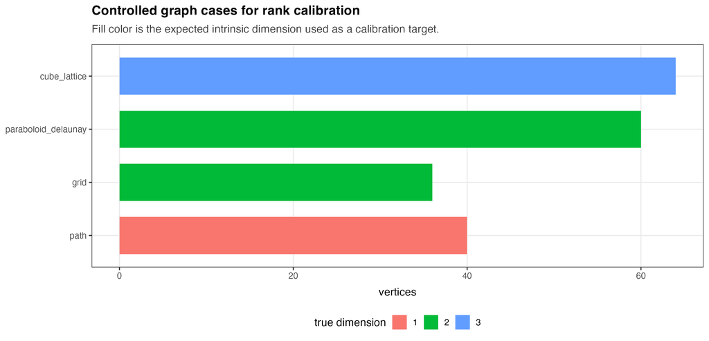

These cases intentionally mix idealized graphs and sampled geometric graphs. The idealized path and grid expose exact structural behavior; the sampled paraboloid and cube lattice test whether the rank rule remains meaningful when graph geometry is less perfectly regular.

# Direction Deficit

The first diagnostic asks whether the rank-aware rule sees missing directions and whether accepted connectors reduce the deficit

$$(m_v-r_v)_+.$$

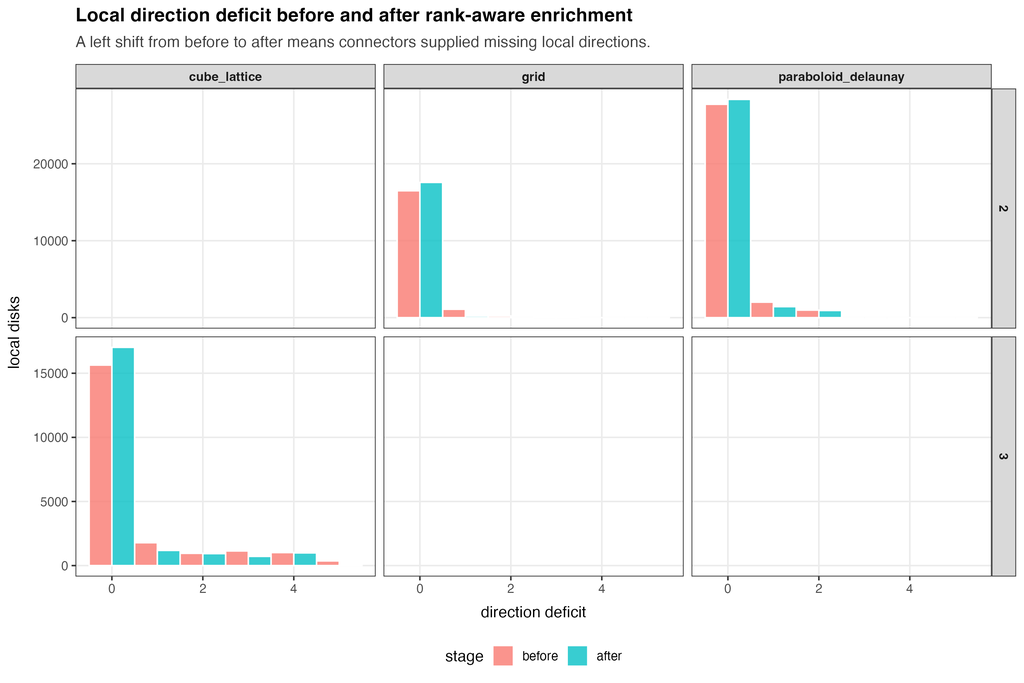

This figure is the most direct calibration check. A path graph should usually have zero deficit. Two- and three-dimensional graphs should show deficits when the base skeleton is too sparse, and those deficits should decrease after rank-aware connectors are added.

# Connector Additions

The connector rule is deterministic. Candidate connectors are scored using rank gain, coverage gain, metric length, and a canonical path key. The next plot shows how often connectors are accepted across the parameter sweep.

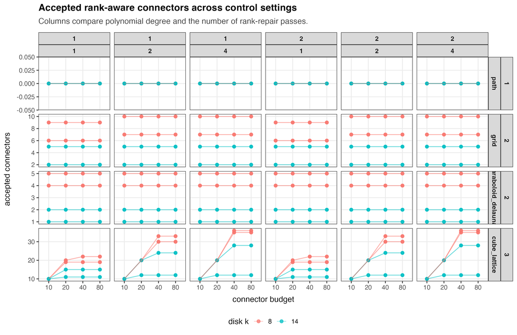

If this plot is zero everywhere, the rank test is too permissive, the base skeleton is already direction-saturated, or the candidate connector pool is too restricted. If connector counts are large everywhere, the rule may be too eager and should be checked against nullity.

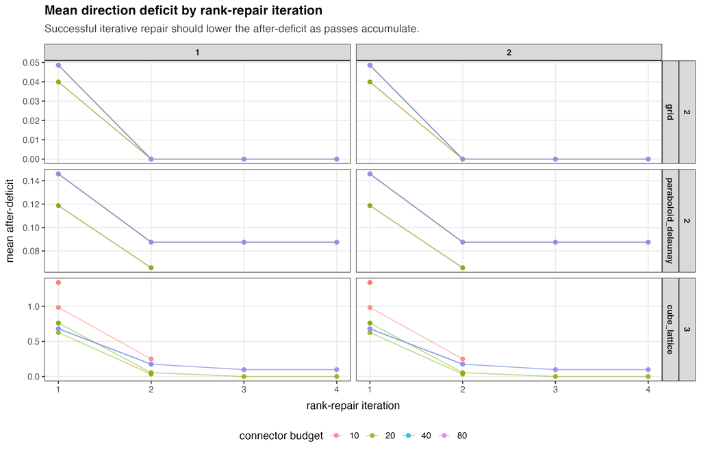

This figure separates connector budget from repeated local repair. If later iterations do not lower the deficit, then additional passes are revisiting disks that are already direction-saturated or unable to generate useful connectors.

# Nullity Calibration

For an intrinsic $m$-dimensional polynomial model of degree $d$, the target dimension is

$$\dim \mathcal P_{\le d}(\mathbb R^m)=\binom{m+d}{m}.$$

This is not a proof target for every graph, but it is the calibration reference for detecting severe under- or over-constraint.

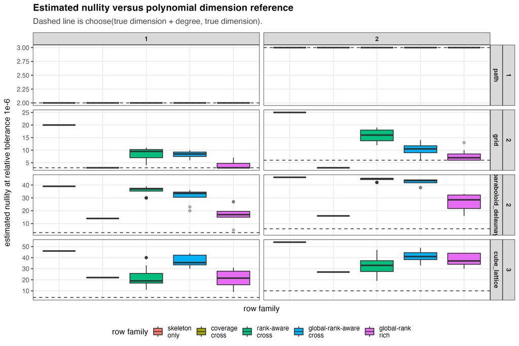

High nullity means the skeleton remains underconstrained. Nullity far below the reference suggests the operator may be destroying the intended polynomial-like null space. The best calibration region should reduce the skeleton-only nullity without collapsing to a trivial null space.

# Polynomial Residuals

The next diagnostic evaluates whether the operator approximately annihilates known intrinsic coordinate polynomials:

$$\frac{\|AP_d\|_F}{\|P_d\|_F}.$$

The control residual uses exact degree $d+1$ monomials, which should generally be larger.

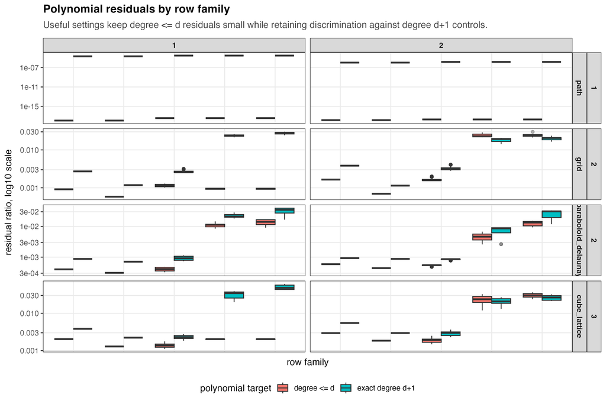

The residual plot guards against a deceptive nullity result. A small nullity is not useful if the operator no longer annihilates the intended polynomial probes.

# Global Rank Selection

The local rank-aware rule asks whether a connector improves the rank inside one disk. The global-rank selector asks the complementary question: does the same candidate add a linearly independent constraint to the assembled operator? At each step it evaluates

$$\Delta_{\mathrm{rank}}(\pi)
=
\mathrm{rank}\{[A;A_\pi]\}-\mathrm{rank}(A),$$

and accepts only candidates with positive global rank gain and acceptable polynomial residual. This is a deliberately expensive calibration tool, not a proposed production solver.

The `global-rank cross` row family uses only the original skeleton-membership connector pool. The `global-rank rich` row family uses the same selector but adds radial, boundary-to-boundary, and annulus-to-boundary local geodesics to the candidate pool.

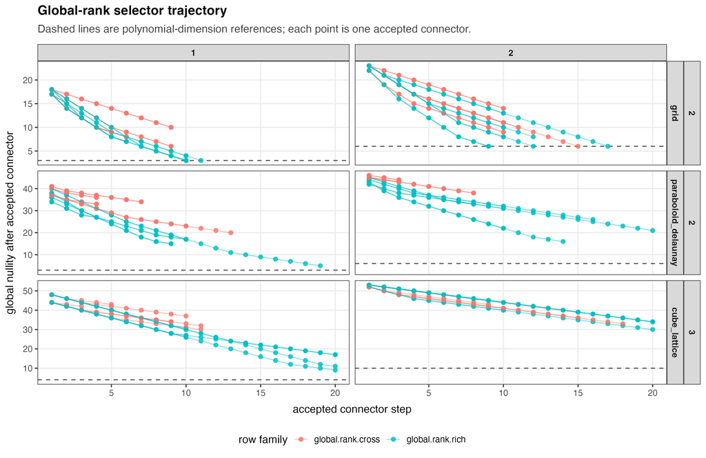

This figure tests whether the global selector can make monotone progress toward the target nullity. A flat trajectory means that the local candidate pool lacks globally independent rows or that the residual guardrail rejects the useful candidates.

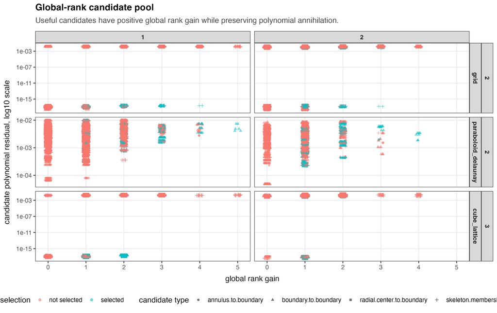

The candidate-pool view is a debugging plot. If most candidates have zero global rank gain, the path generator is producing redundant rows. If many positive-gain candidates have large residuals, the generator is finding constraints that increase rank by damaging the polynomial null space.

# Parameter Sensitivity

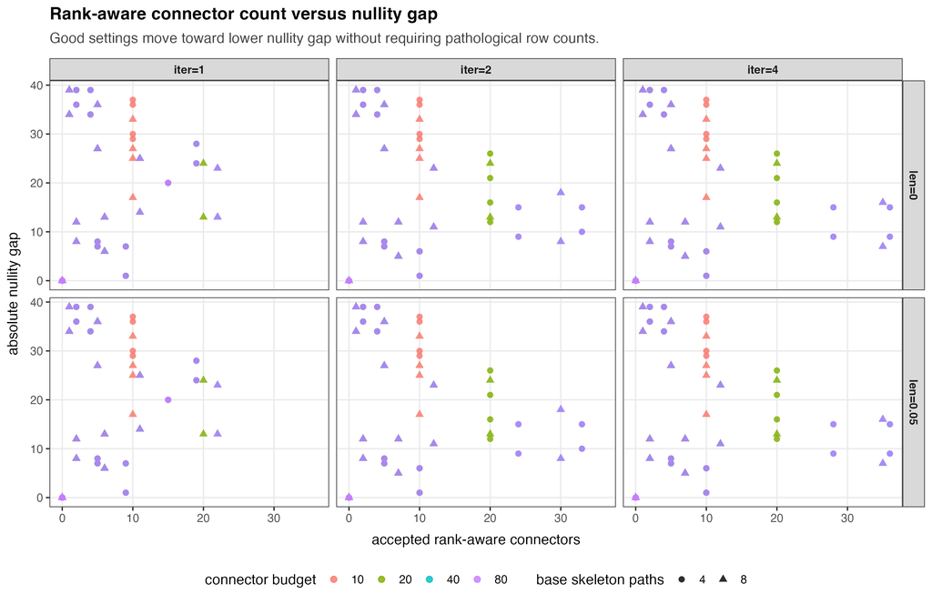

Good settings should move left-to-right enough to reduce nullity, but not so far that nullity collapses below the polynomial reference or residuals deteriorate.

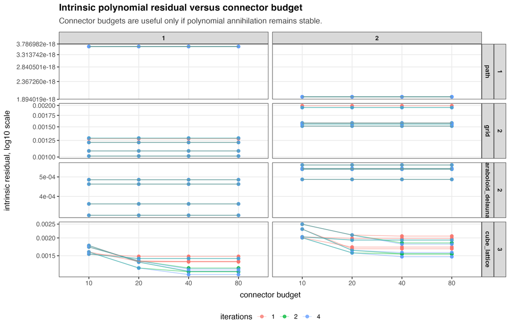

This plot checks the main failure mode of aggressive repair: nullity may improve because the operator is adding many constraints, while the intended polynomial annihilation property quietly worsens.

# What We Learned

| case.id | true.dimension | degree | n.rank.connectors.added | mean.deficit.before | mean.deficit.after | nullity.gap | intrinsic.residual |
| --- | --- | --- | --- | --- | --- | --- | --- |
| grid | 2 | 1 | 5.5 | 0.08681 | 0.00694 | 6.5 | 0.00115 |
| paraboloid_delaunay | 2 | 1 | 3.0 | 0.06875 | 0.02708 | 34.0 | 0.00041 |
| cube_lattice | 3 | 1 | 17.0 | 0.95052 | 0.67088 | 15.0 | 0.00137 |
| grid | 2 | 2 | 5.5 | 0.08681 | 0.00694 | 10.0 | 0.00158 |
| paraboloid_delaunay | 2 | 2 | 3.0 | 0.06875 | 0.02708 | 39.0 | 0.00055 |
| cube_lattice | 3 | 2 | 17.0 | 0.95052 | 0.67088 | 23.0 | 0.00193 |

[output not shown]

| case.id | true.dimension | degree | global.rank.gain | global.nullity.initial | global.nullity.final | nullity.gap | intrinsic.residual | n.global.candidates.scored |
| --- | --- | --- | --- | --- | --- | --- | --- | --- |
| path | 1 | 1 | 0.0 | 2.0 | 2.0 | 0.0 | 0.00000 | 0.0 |
| grid | 2 | 1 | 14.0 | 20.5 | 6.5 | 3.5 | 0.00094 | 634.5 |
| paraboloid_delaunay | 2 | 1 | 14.0 | 41.0 | 25.0 | 22.0 | 0.01175 | 148.5 |
| cube_lattice | 3 | 1 | 17.5 | 48.0 | 30.5 | 26.5 | 0.00203 | 2685.5 |
| path | 1 | 2 | 0.0 | 3.0 | 3.0 | 0.0 | 0.00000 | 0.0 |
| grid | 2 | 2 | 16.0 | 25.0 | 9.0 | 3.0 | 0.02387 | 630.0 |
| paraboloid_delaunay | 2 | 2 | 10.5 | 46.5 | 35.5 | 29.5 | 0.00803 | 85.5 |
| cube_lattice | 3 | 2 | 13.5 | 54.0 | 40.5 | 30.5 | 0.02743 | 1990.0 |

|  | case.id | degree | nullity.gap.global.rank.cross | nullity.gap.global.rank.rich | gap.improvement |
| --- | --- | --- | --- | --- | --- |
| cube_lattice.1.global.rank.cross | cube_lattice | 1 | 26 | 5 | 21 |
| grid.1.global.rank.cross | grid | 1 | 3 | 0 | 3 |
| paraboloid_delaunay.1.global.rank.cross | paraboloid_delaunay | 1 | 17 | 2 | 15 |
| path.1.global.rank.cross | path | 1 | 0 | 0 | 0 |
| cube_lattice.2.global.rank.cross | cube_lattice | 2 | 23 | 20 | 3 |
| grid.2.global.rank.cross | grid | 2 | 0 | 0 | 0 |
| paraboloid_delaunay.2.global.rank.cross | paraboloid_delaunay | 2 | 32 | 10 | 22 |
| path.2.global.rank.cross | path | 2 | 0 | 0 | 0 |

The main Landing 1 lesson is that candidate diversity was a real bottleneck. With the selector held fixed, adding radial, boundary-to-boundary, and annulus-to-boundary candidates gives the global-rank selector many more independent rows to choose from. This is exactly the behavior we wanted to test: the improvement comes from a richer pool, not from changing the selection rule.

The second lesson is that polynomial residuals are the guardrail. In the smoke calibration, aggressive connector settings often kept intrinsic residuals small, which means the new rows are not obviously destroying the polynomial probes. This supports continuing with rank-aware enrichment, but only in tandem with nullity-gap and residual diagnostics.

The third lesson is that 3D remains the hard case. The cube lattice accepts many rank-aware connectors, but its nullity stays well above the polynomial reference for the tested budgets. The global-rank selector directly tests whether the available connector pool contains independent constraints; when it stalls above the reference, the bottleneck is no longer just ranking accepted paths but the geometric diversity of candidate paths.

# Results Summary And Discussion

This calibration separates three questions that were mixed together in the first smoke report. First, does the local dimension/rank diagnostic actually produce deficits? Second, do accepted connectors reduce those deficits? Third, does the resulting operator have plausible nullity and polynomial residuals?

The settings recommended by this report should satisfy all three conditions: visible but not excessive connector additions, lower direction deficits after enrichment, and nullity closer to the polynomial-dimension reference without large increases in $\|AP_d\|_F/\|P_d\|_F$. Settings that only improve one of these diagnostics are not yet good defaults.

# Appendix

## Input Artifact

```r
rds.path
```

```
## [1] "/Users/pgajer/current_projects/gflow/dev/graph-trend-filtering/reports/geodesic_skeleton_rank_calibration_smoke.rds"
```

```r
diagnostics$created
```

```
## [1] "2026-05-18 08:24:41 EDT"
```

## Summary Table

```r
head(summary.table, 80)
```

```
##    case.id family graph.type  n true.dimension expected.nullity row.family
## 1     path   path       path 40              1                2 rank.cross
## 2     path   path       path 40              1                3 rank.cross
## 3     path   path       path 40              1                2 rank.cross
## 4     path   path       path 40              1                3 rank.cross
## 5     path   path       path 40              1                2 rank.cross
## 6     path   path       path 40              1                3 rank.cross
## 7     path   path       path 40              1                2 rank.cross
## 8     path   path       path 40              1                3 rank.cross
## 9     path   path       path 40              1                2 rank.cross
## 10    path   path       path 40              1                3 rank.cross
## 11    path   path       path 40              1                2 rank.cross
## 12    path   path       path 40              1                3 rank.cross
## 13    path   path       path 40              1                2 rank.cross
## 14    path   path       path 40              1                3 rank.cross
```

[output cut: 957 more lines]

## Direction Diagnostics

```r
head(direction.table, 80)
```

[output not shown]

[output cut: 836 more lines]

```
## 1.291            <NA>               NA         0          0.00    NA
## 1.301            <NA>               NA         0          0.00    NA
## 1.311            <NA>               NA         0          0.00    NA
## 1.321            <NA>               NA         0          0.00    NA
## 1.331            <NA>               NA         0          0.00    NA
## 1.341            <NA>               NA         0          0.00    NA
## 1.351            <NA>               NA         0          0.00    NA
## 12               <NA>               NA         0          0.00    NA
## 1.1101    12-11-10-16              0.6         1          3.00 1.300
## 1.258        13-14-15              0.4         1          1.50 1.150
## 1.312            <NA>               NA         0          0.00    NA
## 1.411            <NA>               NA         0          0.00    NA
## 1.511     24-23-22-28              0.6         1          3.00 1.300
## 1.611            <NA>               NA         0          0.00    NA
## 1.711     21-20-19-25              0.6         1          2.00 1.200
```

## Connector Candidates

```r
head(candidate.table, 80)
```

[output not shown]

[output cut: 593 more lines]

```
## 1.65         1          0.75 1.075    FALSE
## 1.66         1          1.25 1.125    FALSE
## 1.67         1          3.00 1.300    FALSE
## 1.68         1          3.25 1.325     TRUE
## 1.69         1          0.50 1.050    FALSE
## 1.70         1          0.75 1.075    FALSE
## 1.71         1          1.00 1.100     TRUE
## 1.72         0          1.25 0.125    FALSE
## 1.73         1          0.75 1.075    FALSE
## 1.74         1          0.50 1.050    FALSE
## 1.75         1          0.75 1.075    FALSE
## 1.76         1          1.00 1.100    FALSE
## 1.77         1          1.00 1.100    FALSE
## 1.78         1          0.75 1.075    FALSE
## 1.79         0          1.00 0.100    FALSE
```

## Global Rank Candidates

```r
head(global.candidate.table, 80)
```

[output not shown]

[output cut: 674 more lines]

```
## 1.65 1.039882    FALSE              TRUE   not selected
## 1.66 1.039882    FALSE              TRUE   not selected
## 1.67 3.039882    FALSE              TRUE   not selected
## 1.68 1.039882    FALSE              TRUE   not selected
## 1.69 2.029382    FALSE              TRUE   not selected
## 1.70 2.029382    FALSE              TRUE   not selected
## 1.71 2.029382    FALSE              TRUE   not selected
## 1.72 2.029382    FALSE              TRUE   not selected
## 1.73 1.033500     TRUE             FALSE       selected
## 1.74 3.389882    FALSE              TRUE   not selected
## 1.75 3.389882    FALSE              TRUE   not selected
## 1.76 3.389882    FALSE              TRUE   not selected
## 1.77 2.379382    FALSE              TRUE   not selected
## 1.78 1.379382    FALSE              TRUE   not selected
## 1.79 2.379382    FALSE              TRUE   not selected
```

## Global Rank Selections

```r
head(global.selection.table, 80)
```

[output not shown]

[output cut: 755 more lines]

```
## 1.76                 6            16
## 1.86                 6            15
## 1.94                 6            14
## 17                   6            23
## 1.116                6            21
## 1.27                 6            20
## 1.37                 6            19
## 1.47                 6            18
## 1.57                 6            17
## 1.67                 6            16
## 1.77                 6            15
## 1.87                 6            14
## 1.95                 6            13
## 18                   3            17
## 1.117                3            14
```